# Bioconductor submissions

Lluís Revilla Sancho

2020-06-15

The other day I was curious about how many submissions are on Bioconductor and how do they work, is there any pattern toward the release cycle or not? In this brief post I’ll explore some data available from the [github repository](https://github.com/Bioconductor/Contributions/) where the submissions are done as issues. I mostly focus on what happens when one submits a package so that it can help future submissions.

There are around 1507 issues, I extract the interesting information: date of creation, who creates them, where is the linked package. when are they closed, labels at the moment, reviewers…

We can further makr those approved because they are on bioconductor but do not have the [approved label](https://github.com/Bioconductor/Contributions/labels/3a.%20accepted) (Sometimes they get accepted but they forget to change labels on the issue).

I didn’t mark as accepted packages that were submitted several times (154 packages have been submitted more than once). Some of them are due to being on the old tracker and were not approved on this repository.  
Using also the CRAN repository we could find which packages where submitted to Bioconductor but end up on CRAN. But as I expect a low number of these I won’t check them.

## Exploring the submissions

First of all a general overview of the data available:

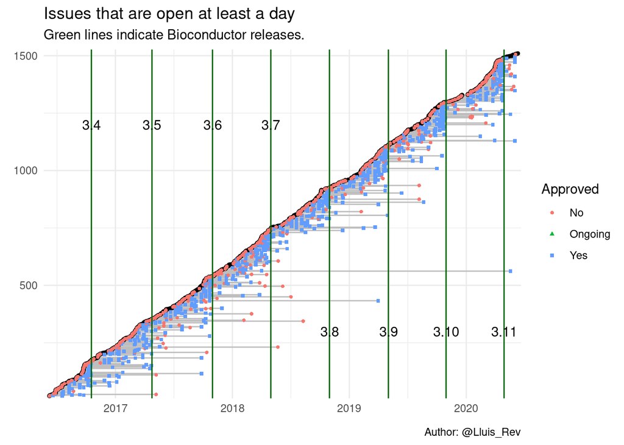

On this plot we can see almost everything, date of creation, time opened, when was closed, in which release is included if accepted and the rate of submissions to Bioconductor. What we miss is about the authors submitting the packages and about the packages themselves.

## Submitting authors

One of the core strength of R is the open community. There have been 765 different users submitting at least one package.

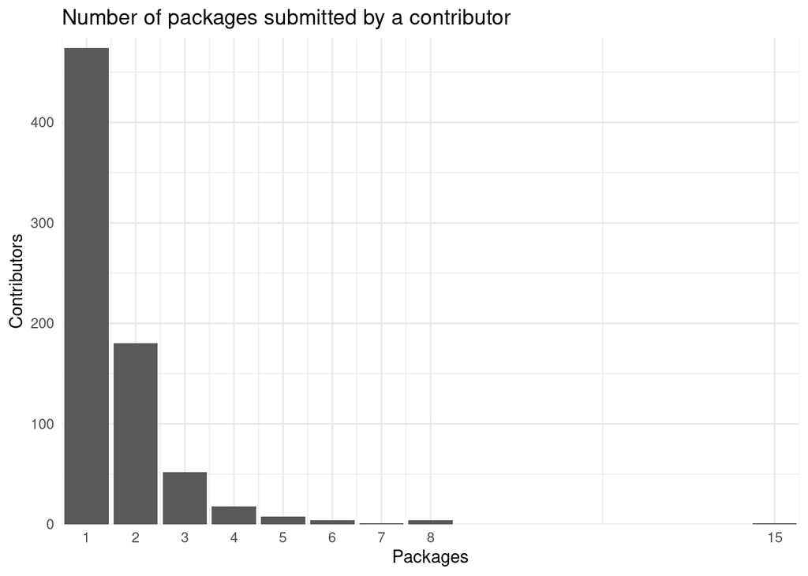

We can clearly see that most authors submit just one package but some submit a few more, with an outlier who have submitted more than 10 packages.

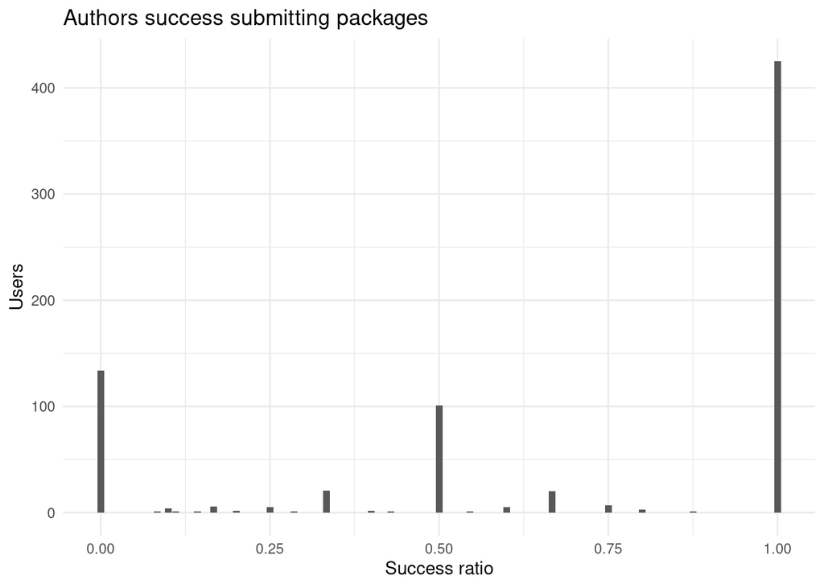

Most of the authors get their submission included at Bioconductor at the first try. Few need two submissions and some do not get their package included on Bioconductor. This can be because they withdraw the submission, or they decide to submit elsewhere or simply they do not go through the review.

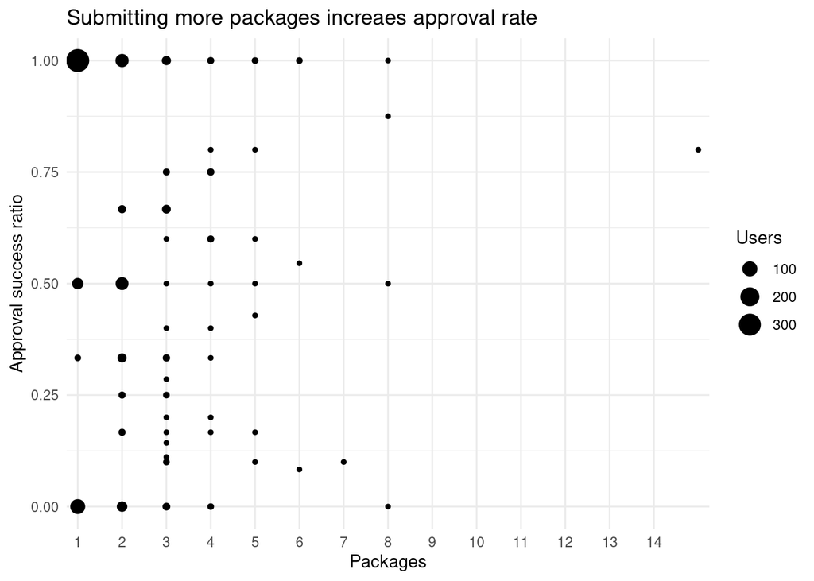

If authors submit more packages they usually get them approved. Although we can also see some users that make several submissions.

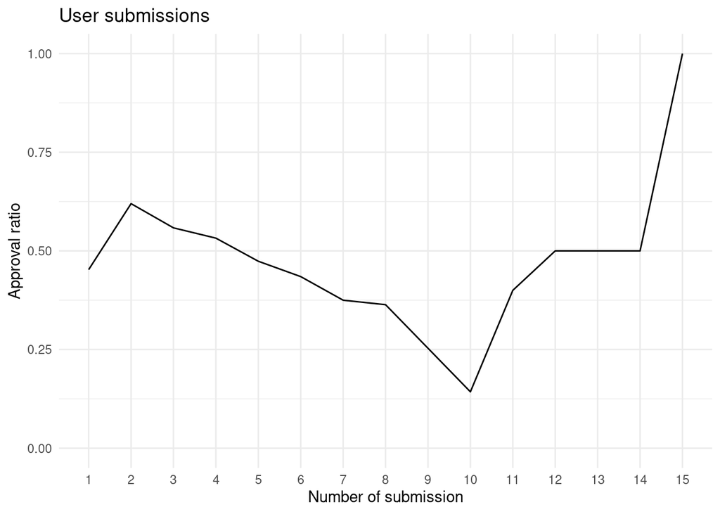

Regardless if the package is submitted just once or several times. More submissions do not make the package get accepted. Make sure that the submission is right on the first or second try. One big source of errors is not changing the template name of the repository for a link to your repository.

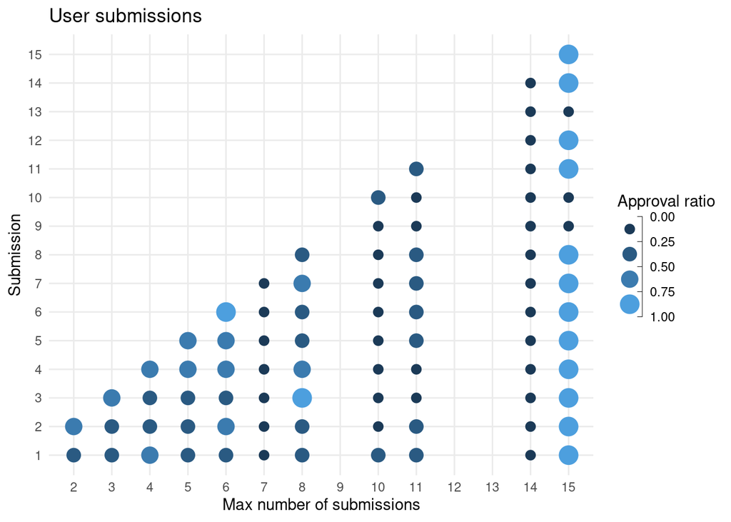

We can see that some users that created 14 issues didn’t have any package approved.

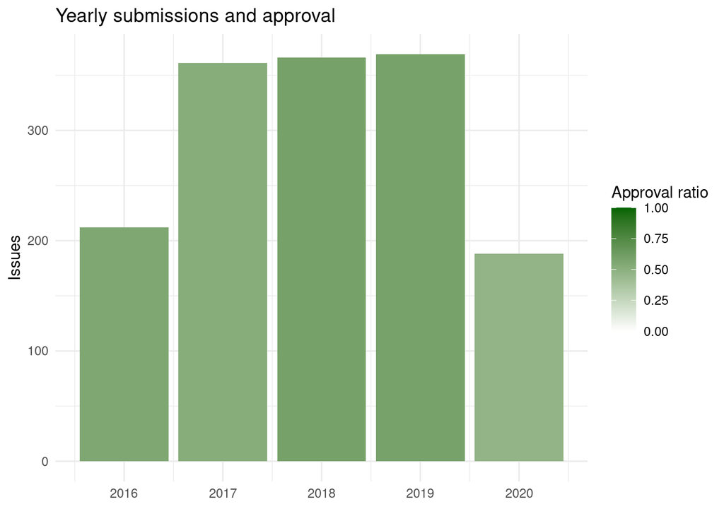

Around 50% of the ~400 yearly packages submitted are approved.

So if you have a package that fits Bioconductor you’ll get fairly well on the submission process. But I always recommend the lengthy pages for developers about the [submission process](https://bioconductor.org/developers/package-submission/) and the [packages guidelinines and requirements](https://bioconductor.org/developers/package-guidelines/). Also make sure that you understand the expectations on what to fill of the template and what to expect after submitting: Don’t post several issues for the same package if you haven’t got any reply, but you can send a reminder on the issue and an email to the mailing list. Many times the reason for not accepting a package is because they do not follow the guidelines.

# Reviewers

If your package fits Bioconductor a bot will assign a reviewer to check the package. Many submissions (~33%) do not get a reviewer assigned and the package is not included on Bioconductor’s repository, most (~90%) of the cases this happens the same day of the submission. But once they get one reviewer ~82% of them are approved.

There core members of Bioconductor are 9 usual reviewers:

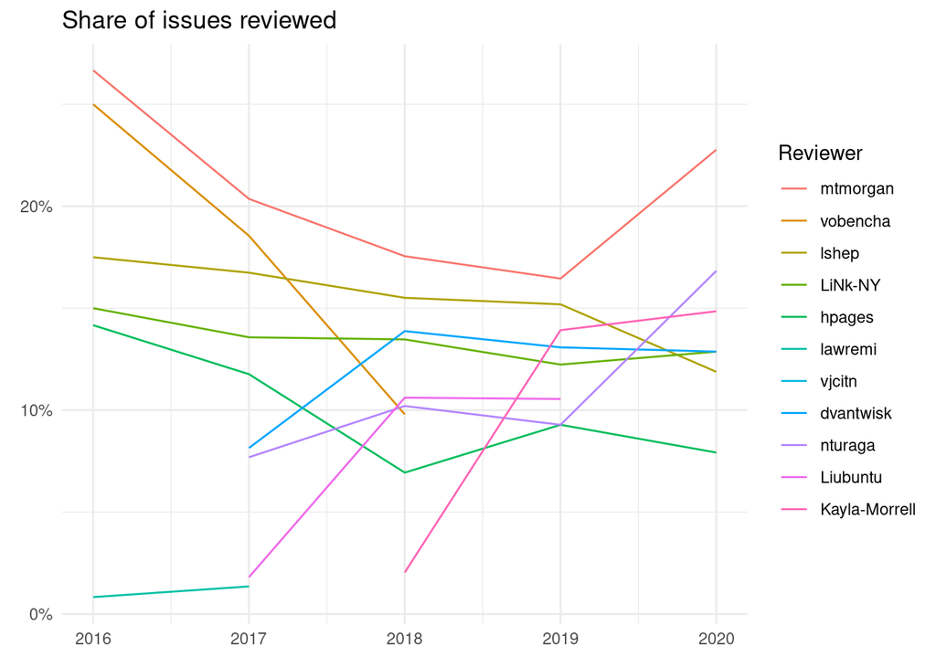

Probably you might get assigned the project leader Martin Morgan, but you can work with any other reviewer, as the work load is quite distributed: mtmorgan, lshep, LiNk-NY, dvantwisk, vobencha, hpages, nturaga, Liubuntu, Kayla-Morrell.

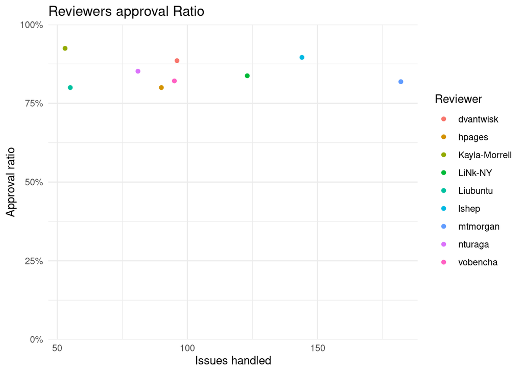

The reviews are fairly done by all the members. We can see that all of them approves more than 75% of the packages assigned.

Most of the reviewers take few days until the issue is closed.

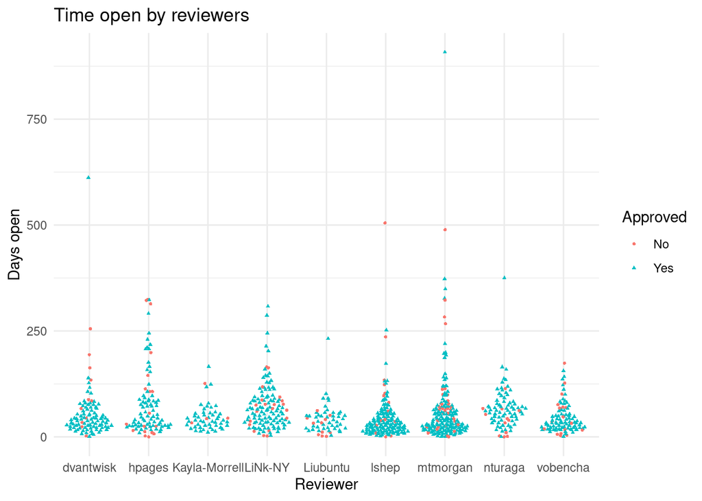

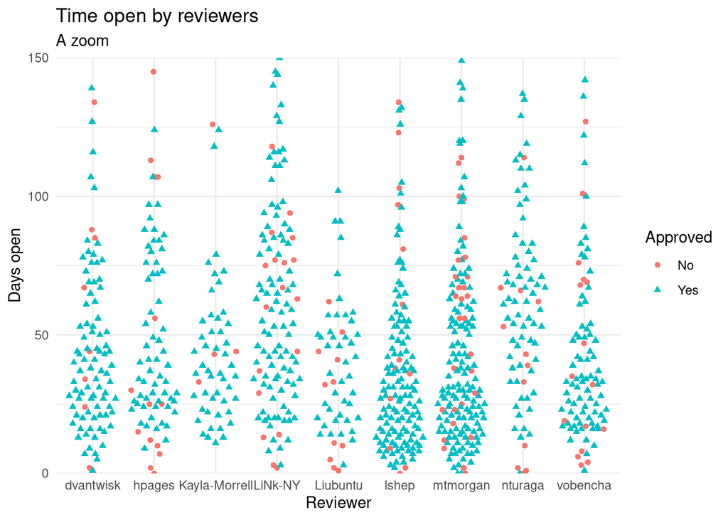

Looking at these plots more time reviewing do not mean closing the issue without being accepted.

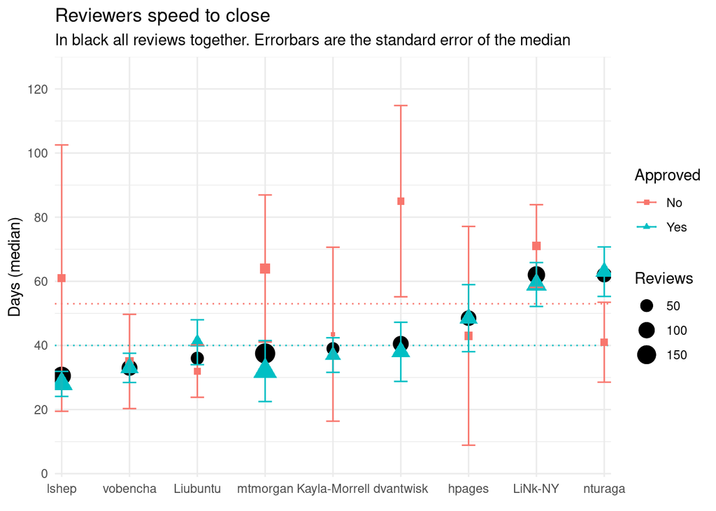

Correction! If we divide by approved submissions, some reviewers close later submissions that are not approved. They might wait longer to close the issues without approving them, or maybe they prefer to suggest modifications and a second submission of the same package. Others close faster than they accept the packages but as you can see by the error bars it is quite variable. In general you can expect more than 40 days review.

They might accept faster packages but it is because they provide faster feedback with more comments?

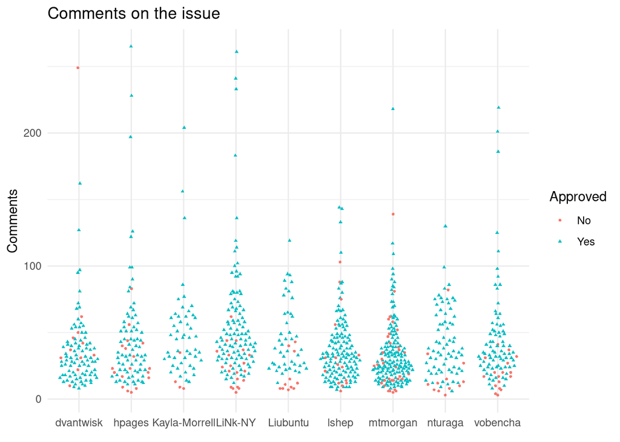

Many of the comments I suspect are automatic messages from the bot about building and receiving commits. But apparently there isn’t a difference between them.

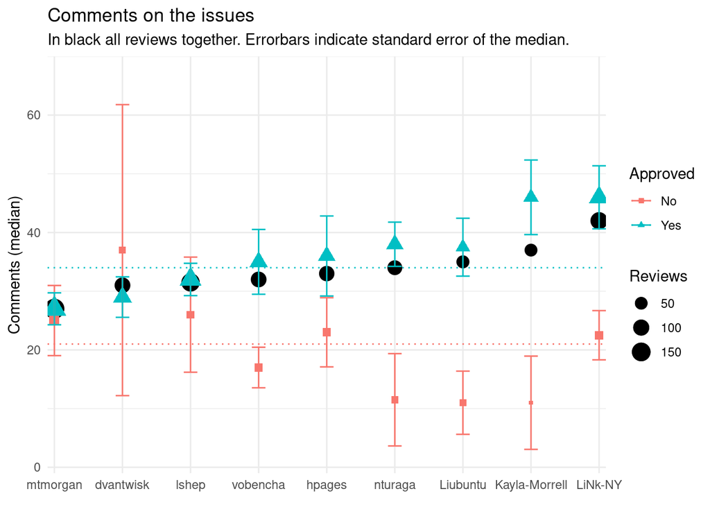

Here almost all the reviewers have more comments on approved packages. Also, there is less variability on the number of comments than on the time they are open. Answering doubts and giving feedback to the reviewers and contributors increases acceptance, even if this comment increase is due to automatic messages.

Taking both information together we can see the pattern for all the reviewers:

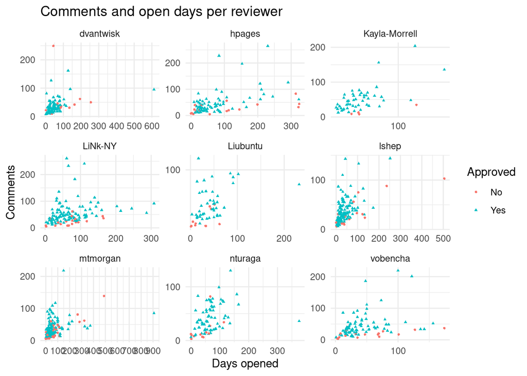

## Rushing?

Reviewers take their time to accept or reject the packages. But do contributors have some rush to get them accepted at the end of an academic year, before a Bioconductor release or before a publication? While I cannot check if there is an article accompanying the package, I can check other time trends.

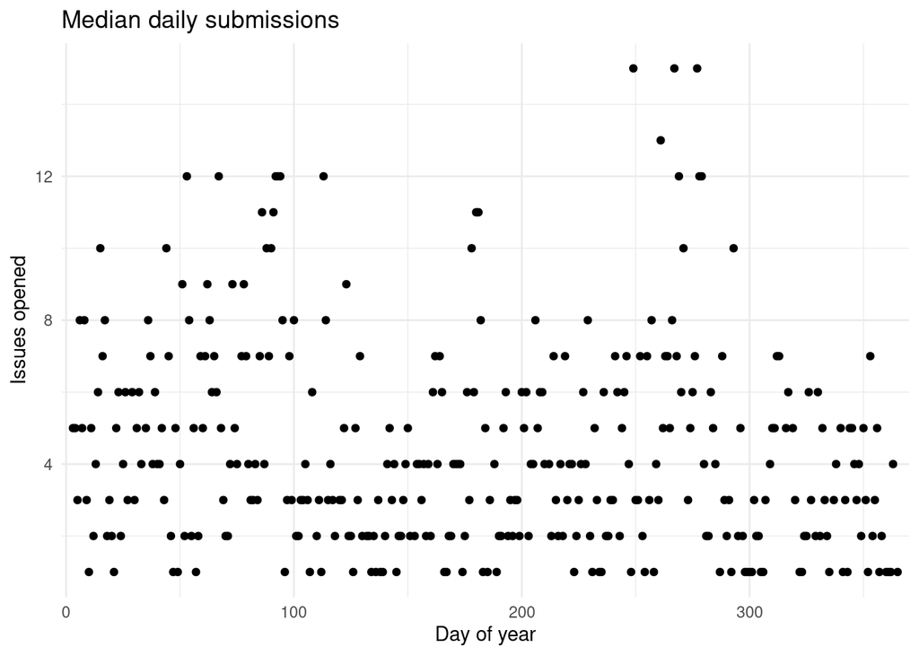

Using the dates of new [Bioconductor releases](https://bioconductor.org/about/release-announcements/) we can check if there is some rush to submit packages closer to the new release:

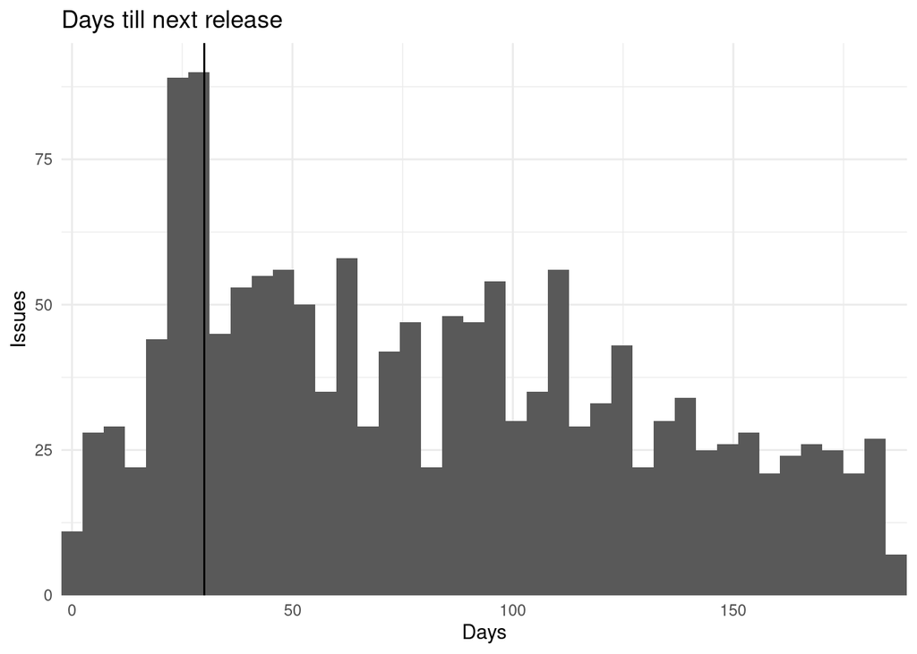

The vertical line indicates the usual time the submissions are no longer accepted (around 30 days before the release day). So it seems like people submit close to the date but much consistently around the year as previously seen.

Those that submit closer to the date of release have higher rates of not being included on Bioconductor.

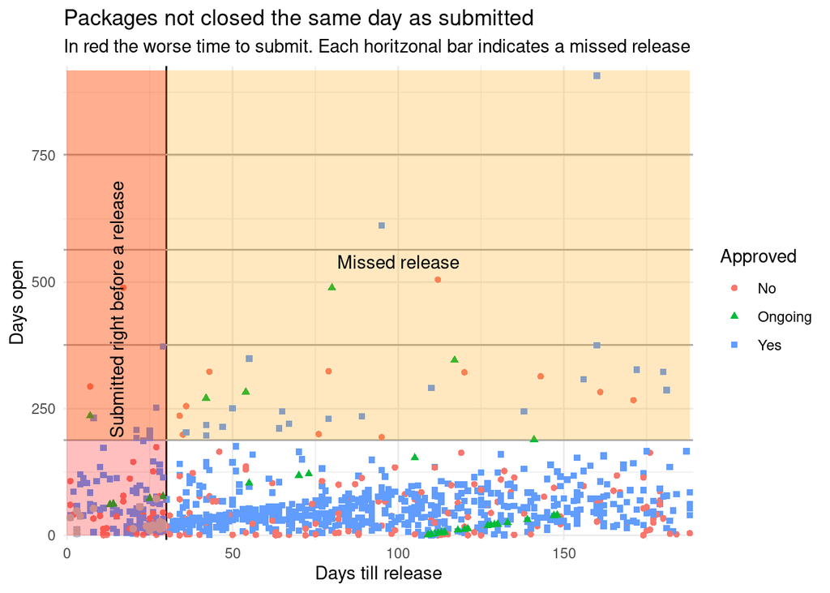

Very few packages went to the worst scenario: submitted right before a deadline and then it wasn’t accepted until many releases later. However there is a curious effect, the closer the submission is to the release day, the shorter are the reviews of the accepted packages.

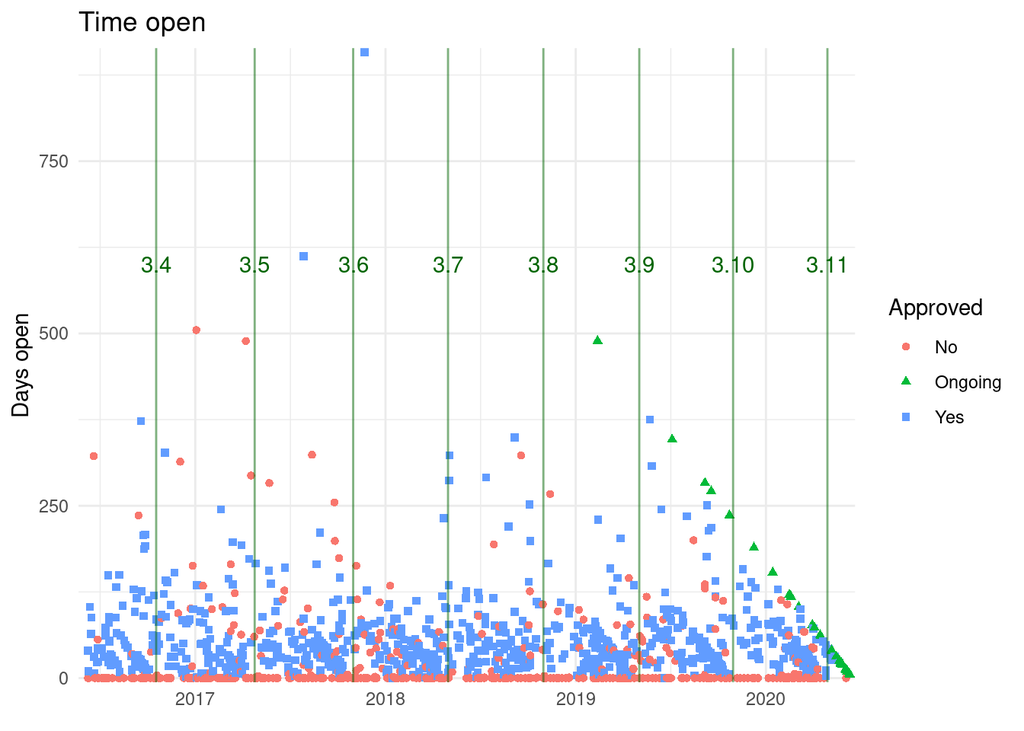

Here we can observe this effect on the latest release.

I expected to see longer review time for the issues submitted closer to the release but we don’t see it. This indicates a sustained effort to review the submissions.

## Pitfalls

We have seen mostly the path to success, but in order to improve the process we must look what lead to having the packages not approved.

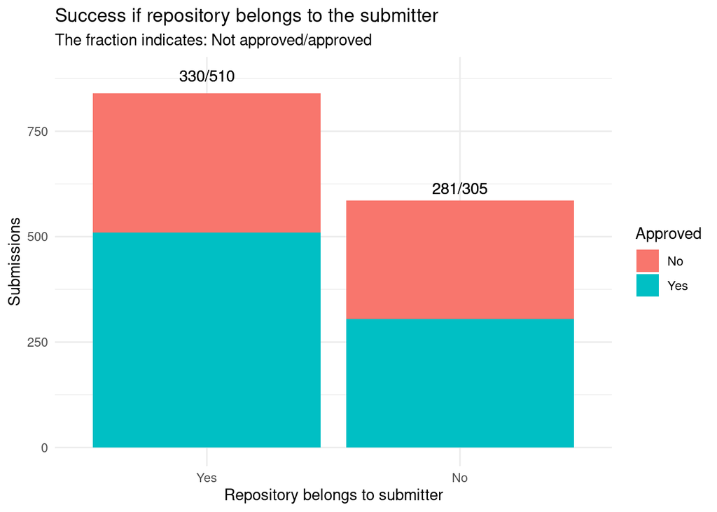

When the user that submits the package is the owner of the repository then it is more likely that the package is accepted. Probably because it is easier to manage the version control system that way.

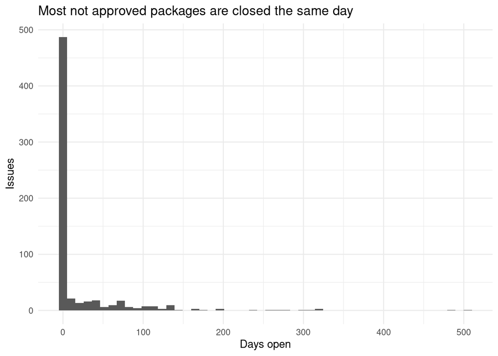

Most packages are closed fast but some review take longer than a year! Those closed fast are automatically done by the bot due to several reasons. Among these reasons:

Issues with more than one package

| Number of packages | Times |
| --- | --- |
| 0 | 15 |
| 2 | 15 |
| 3 | 1 |

| Name | Packages |
| --- | --- |
| yourpackagename | 87 |
| Trumpet | 13 |
| BioMedR | 7 |
| SVAPLSseq | 6 |
| PoTRA | 6 |
| spbtest3 | 4 |

It is equally probable to not provide a link or to provide two. However many times the template is used as is and the link to the name of the repository remains “yourpackagename”, which is detected by the bot and closed.

| Comments | Issues |
| --- | --- |
| 1 | 388 |
| 2 | 44 |
| 3 | 25 |
| 4 | 13 |
| 6 | 12 |
| 5 | 10 |

Most of the rejected submissions is done automatically by the “bioc-issue-bot”, with a brief message. But in general few messages are written before closing the submissions.

Ending of rejected issues

| Ending | Number of issues |
| --- | --- |
| .git | 29 |
| .R | 4 |
| .0.99.0 | 2 |
| .data.oma.All.Jan2020 | 2 |
| .0 | 1 |
| .2 | 1 |

Sometimes the user provides a link to a compressed file, or it ends incorrectly with .git as when the url need to clone a repository.

Labels of rejected packages

| Number of labels | Number of issues |
| --- | --- |
| 0 | 425 |
| 1 | 83 |
| 2 | 78 |
| 3 | 50 |
| 4 | 5 |
| 5 | 1 |

The bot automatically labels the issues to provide information about the build and check of the package and about the stage of the project. Usually this means they do not get assigned a reviewer or built on the Bioconductor server.

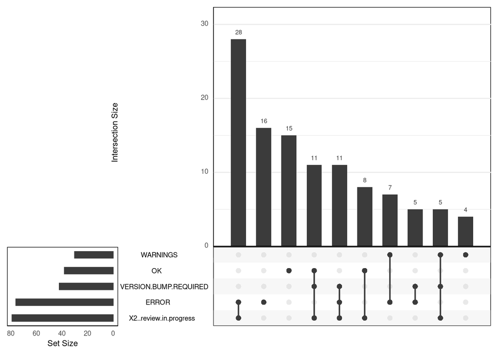

Looking at which labels go together, if the review starts the next halting point is an error on the build process, probably the issue is not fixed and the submission not approved.

## Conclusion

Most of the packages submitted to Bioconductor are accepted. Those that are not accepted are usually due to submission formatting issues detected automatically by the bioc-issue-bot. Reviewers provide a lot of feedback that if followed leads to acceptance of the package, when this feedback is ignored it leads to a rejection of the submission. Some packages are submitted right before a release and miss it, while others undergo a long review and miss several releases, but if you want to have your package included on the next release, aim to submit 40 days before the release date (usually on the end of April and October).